# COMPSCIX 415.2 Homework 6

Sharmistha Maitra

3/8/2018

```r
library(tidyverse)
library(mosaicData)
library(datasets)
```

# **Exercise 1**

# Load the Whickham dataset (data(Whickham)). You will need to load the mosaicData package first, but I also included the data as an rds file on Canvas if you would rather download it there and load it with readRDS(). Look at the help file on this dataset to learn a bit about it.

## 1.What variables are in this data set?

```r
#The variables are:

#outcome - survival status after 20 years: a factor with levels Alive Dead

#smoker - smoking status at baseline: a factor with levels No Yes

#age  - age (in years) at the time of the first survey
```

## 2.How many observations are there and what does each represent?

```r
#There are 1314 obervations.The observations represent one-in-six survey on women in Whickham, UK. Age and smoking status was noted down for each women at the time of first survey. Then after 20 years, same women were surveyed again to note the outcome , if they were alive or dead.
```

## 3.Create a table (use the R code below as a guide) and a visualization of the relationship between smoking status and outcome, ignoring age. What do you see? Does it make sense?

```r
#The graph below shows the Visualization of smoking status and outcome(ignoring age). If I compare the graph between smokers and non-smokers, the proportion of women dead (who were non-smokers) is more than proportion of women dead (who were smokers) . In other words, I see an increaded mortality rate for non-smoking women compared to smoking wome, which doesnt seem to make sense.

#Whickham_1 <- Whickham %>% mutate(age_fct) %>% group_by(age) %>% arrange(age)
#Whickham_1


smoker_outcome <- Whickham %>%
                      group_by(smoker, outcome, age) %>%
                      arrange(smoker, outcome, age) %>%
                      summarize(
                        count = n()
                      )
smoker_outcome
```

```
## # A tibble: 205 x 4
## # Groups:   smoker, outcome [?]
##    smoker outcome   age count
##    <fctr>  <fctr> <int> <int>
##  1     No   Alive    18    10
##  2     No   Alive    19     8
##  3     No   Alive    20    11
##  4     No   Alive    21     8
##  5     No   Alive    22     8
##  6     No   Alive    23    12
##  7     No   Alive    24    14
##  8     No   Alive    25    14
##  9     No   Alive    26    13
## 10     No   Alive    27    19
## # ... with 195 more rows
```

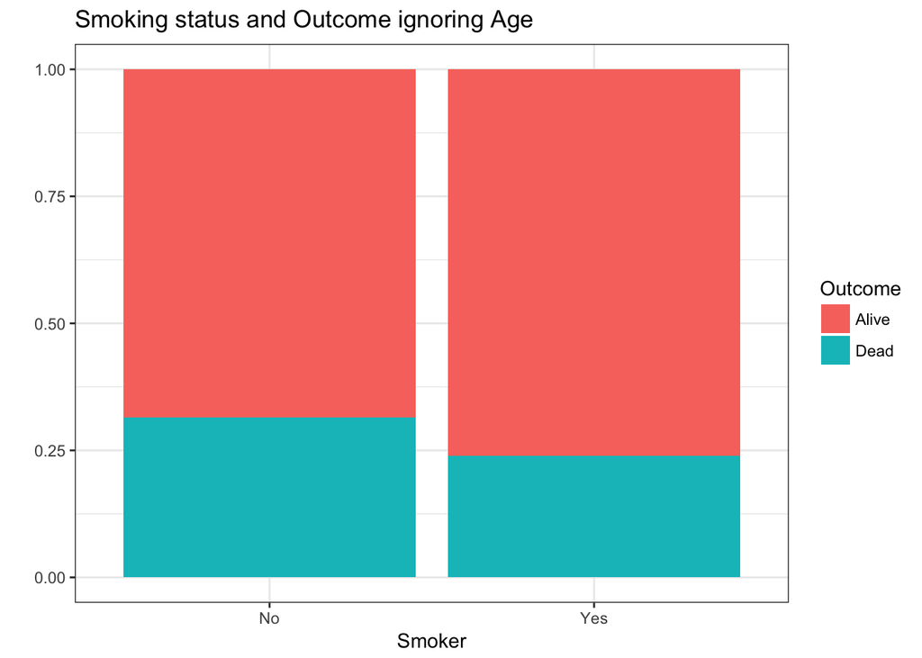

```r
#Smoking status and outcome, ignoring age. Shows increased mortality rate amongst non-smoking women.
ggplot(data = smoker_outcome, mapping = aes(x = smoker, y = count, fill = outcome)) +
geom_bar(stat = 'identity', position = 'fill') +
  labs(x = 'Smoker', y = '', fill = 'Outcome',
       title = 'Smoking status and Outcome ignoring Age') +
  theme_bw()
```

## 4.Recode the age variable into an ordered factor with three categories: age <= 44, age > 44 & age <= 64, and age > 64. Now, recreate visualization from above, but facet on your new age factor. What do you see? Does it make sense?

```r
#Creating age factor with three levels
age_cat <- case_when(Whickham$age <= 44 ~ '<=44',
                   Whickham$age > 44 & Whickham$age <= 64 ~ '44<age<=64',
                   Whickham$age > 64 ~ '>64')

age_fct <- factor(age_cat, ordered = TRUE)


Whickham_1 <- Whickham %>% mutate(age_fct) %>% group_by(age) %>% arrange(age)
Whickham_1
```

```
## # A tibble: 1,314 x 4
## # Groups:   age [67]
##    outcome smoker   age age_fct
##     <fctr> <fctr> <int>   <ord>
##  1   Alive    Yes    18    <=44
##  2   Alive     No    18    <=44
##  3   Alive    Yes    18    <=44
##  4   Alive    Yes    18    <=44
##  5   Alive    Yes    18    <=44
##  6   Alive     No    18    <=44
##  7   Alive     No    18    <=44
##  8   Alive     No    18    <=44
##  9   Alive     No    18    <=44
## 10   Alive     No    18    <=44
## # ... with 1,304 more rows
```

```r
smoker_outcome <- Whickham_1 %>%
                      group_by(smoker, outcome, age_fct) %>%
                      arrange(smoker, outcome, age_fct) %>%
                      summarize(
                        count = n()
                      )
smoker_outcome
```

```
## # A tibble: 12 x 4
## # Groups:   smoker, outcome [?]
##    smoker outcome    age_fct count
##    <fctr>  <fctr>      <ord> <int>
##  1     No   Alive       <=44   327
##  2     No   Alive        >64    28
##  3     No   Alive 44<age<=64   147
##  4     No    Dead       <=44    12
##  5     No    Dead        >64   165
##  6     No    Dead 44<age<=64    53
##  7    Yes   Alive       <=44   270
##  8    Yes   Alive        >64     6
##  9    Yes   Alive 44<age<=64   167
## 10    Yes    Dead       <=44    15
## 11    Yes    Dead        >64    44
## 12    Yes    Dead 44<age<=64    80
```

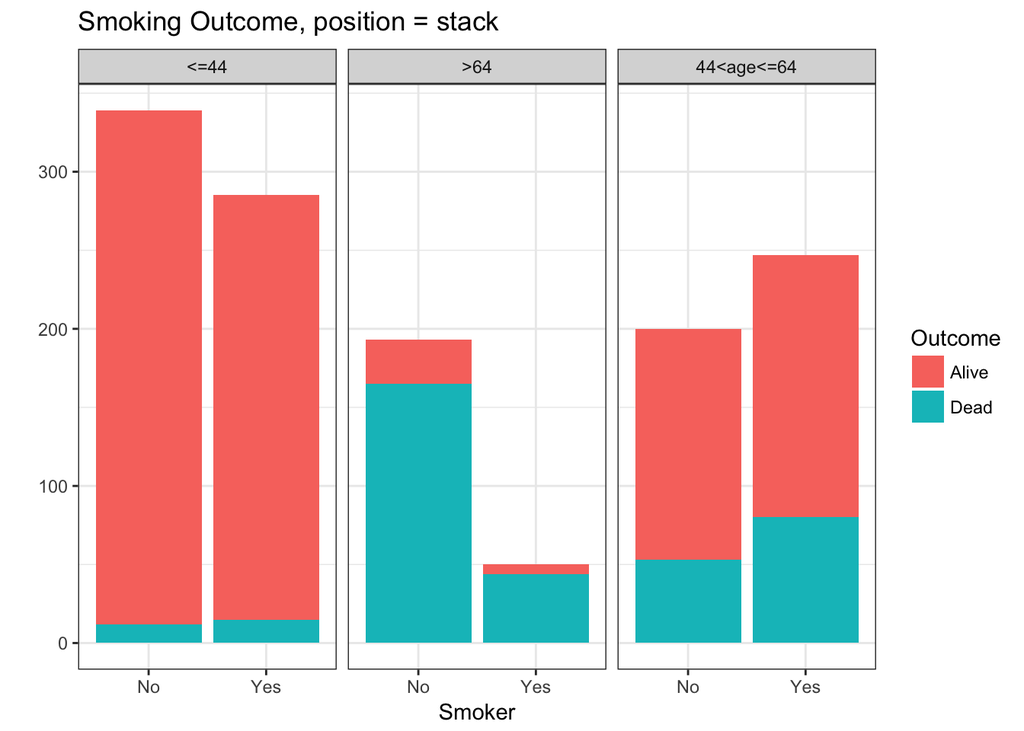

```r
#Graph1: Smoking status and outcome, considering age (comparing real numbers, using position = 'stack' )
#Here, I have compared the real numbers, by using position = 'stack' in geom_bar(), but results are hard to read and come to a conclusion using this graph.
ggplot(data = smoker_outcome, mapping = aes(x = smoker, y = count, fill = outcome)) +
  geom_bar(stat = 'identity', position = 'stack') +
  facet_grid(~ age_fct) +
  labs(x = 'Smoker', y = '', fill = 'Outcome',
       title = 'Smoking Outcome, position = stack') +
  theme_bw()
```

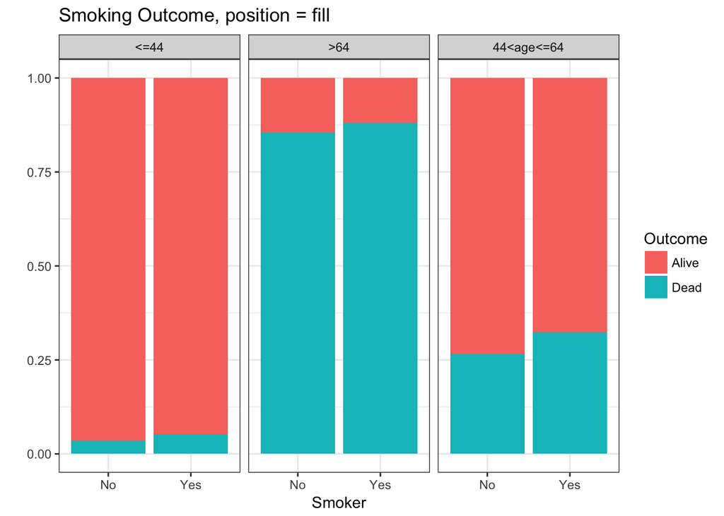

```r
#Graph2: Smoking status and outcome, considering age (comparing proportions, using position = 'fill' )
#Here, I have compared the proportions, by using position = 'fill' in geom_bar(). Now the results are easy to read because position_fill shows relative proportions at each x by stacking the bars and then standardising each bar to have the same height. Graph2 does make sense, as I see higher mortality rate for women who were smokers.

ggplot(data = smoker_outcome, mapping = aes(x = smoker, y = count, fill = outcome)) +
  geom_bar(stat = 'identity', position = 'fill') +
  facet_grid(~ age_fct) +
  labs(x = 'Smoker', y = '', fill = 'Outcome',
       title = 'Smoking Outcome, position = fill') +
  theme_bw()
```